# Title:- Prediction of Heart Disease

Aim:- The goal of the project is to predict whether that person will have coronary heart disease in upcoming 10 years

# Project Description:-

The dataset is publically available.It contains patient’s information and contains total 4240 records and 15 features. Features includes Gender, Age , Education ,Cigs_Per_day, Current_Smoker, Sys_BP, Dia_BP, Heart_rate, Glucose…etc.People have various problems regarding heath. The goal of the project is to predict whether that person will have coronary heart disease in upcoming 10 years.The Target variable is TenYearCHD. We have to clean the data and apply all the algorithms to our model and check which one gives maximum accuracy.

# Import Basic Libraries

```python
import pandas as pd
import numpy as np
import matplotlib.pyplot as plt
import seaborn as sns
import warnings
warnings.filterwarnings('ignore')
```

# 1) Acquire the Data

```python
df=pd.read_csv("framingham.csv.csv")
```

```python
df.head()
```

|  | male | age | education | currentSmoker | cigsPerDay | BPMeds | prevalentStroke | prevalentHyp | diabetes | totChol | sysBP | diaBP | BMI | heartRate | glucose | TenYearCHD |
| --- | --- | --- | --- | --- | --- | --- | --- | --- | --- | --- | --- | --- | --- | --- | --- | --- |
| 0 | 1 | 39 | 4.0 | 0 | 0.0 | 0.0 | 0 | 0 | 0 | 195.0 | 106.0 | 70.0 | 26.97 | 80.0 | 77.0 | 0 |
| 1 | 0 | 46 | 2.0 | 0 | 0.0 | 0.0 | 0 | 0 | 0 | 250.0 | 121.0 | 81.0 | 28.73 | 95.0 | 76.0 | 0 |
| 2 | 1 | 48 | 1.0 | 1 | 20.0 | 0.0 | 0 | 0 | 0 | 245.0 | 127.5 | 80.0 | 25.34 | 75.0 | 70.0 | 0 |
| 3 | 0 | 61 | 3.0 | 1 | 30.0 | 0.0 | 0 | 1 | 0 | 225.0 | 150.0 | 95.0 | 28.58 | 65.0 | 103.0 | 1 |
| 4 | 0 | 46 | 3.0 | 1 | 23.0 | 0.0 | 0 | 0 | 0 | 285.0 | 130.0 | 84.0 | 23.10 | 85.0 | 85.0 | 0 |

```python
df.tail()
```

|  | male | age | education | currentSmoker | cigsPerDay | BPMeds | prevalentStroke | prevalentHyp | diabetes | totChol | sysBP | diaBP | BMI | heartRate | glucose | TenYearCHD |
| --- | --- | --- | --- | --- | --- | --- | --- | --- | --- | --- | --- | --- | --- | --- | --- | --- |
| 4235 | 0 | 48 | 2.0 | 1 | 20.0 | NaN | 0 | 0 | 0 | 248.0 | 131.0 | 72.0 | 22.00 | 84.0 | 86.0 | 0 |
| 4236 | 0 | 44 | 1.0 | 1 | 15.0 | 0.0 | 0 | 0 | 0 | 210.0 | 126.5 | 87.0 | 19.16 | 86.0 | NaN | 0 |
| 4237 | 0 | 52 | 2.0 | 0 | 0.0 | 0.0 | 0 | 0 | 0 | 269.0 | 133.5 | 83.0 | 21.47 | 80.0 | 107.0 | 0 |
| 4238 | 1 | 40 | 3.0 | 0 | 0.0 | 0.0 | 0 | 1 | 0 | 185.0 | 141.0 | 98.0 | 25.60 | 67.0 | 72.0 | 0 |
| 4239 | 0 | 39 | 3.0 | 1 | 30.0 | 0.0 | 0 | 0 | 0 | 196.0 | 133.0 | 86.0 | 20.91 | 85.0 | 80.0 | 0 |

# Exploring the data set in order to derive useful information

```python
df.shape
```

```
(4240, 16)
```

This shows our data has 4240 rows and 16 columns

```python
df.columns
```

```
Index(['male', 'age', 'education', 'currentSmoker', 'cigsPerDay', 'BPMeds',
       'prevalentStroke', 'prevalentHyp', 'diabetes', 'totChol', 'sysBP',
       'diaBP', 'BMI', 'heartRate', 'glucose', 'TenYearCHD'],
      dtype='object')
```

```python
df.describe()
```

|  | male | age | education | currentSmoker | cigsPerDay | BPMeds | prevalentStroke | prevalentHyp | diabetes | totChol | sysBP | diaBP | BMI | heartRate | glucose | TenYearCHD |
| --- | --- | --- | --- | --- | --- | --- | --- | --- | --- | --- | --- | --- | --- | --- | --- | --- |
| count | 4240.000000 | 4240.000000 | 4135.000000 | 4240.000000 | 4211.000000 | 4187.000000 | 4240.000000 | 4240.000000 | 4240.000000 | 4190.000000 | 4240.000000 | 4240.000000 | 4221.000000 | 4239.000000 | 3852.000000 | 4240.000000 |
| mean | 0.429245 | 49.580189 | 1.979444 | 0.494104 | 9.005937 | 0.029615 | 0.005896 | 0.310613 | 0.025708 | 236.699523 | 132.354599 | 82.897759 | 25.800801 | 75.878981 | 81.963655 | 0.151887 |
| std | 0.495027 | 8.572942 | 1.019791 | 0.500024 | 11.922462 | 0.169544 | 0.076569 | 0.462799 | 0.158280 | 44.591284 | 22.033300 | 11.910394 | 4.079840 | 12.025348 | 23.954335 | 0.358953 |
| min | 0.000000 | 32.000000 | 1.000000 | 0.000000 | 0.000000 | 0.000000 | 0.000000 | 0.000000 | 0.000000 | 107.000000 | 83.500000 | 48.000000 | 15.540000 | 44.000000 | 40.000000 | 0.000000 |
| 25% | 0.000000 | 42.000000 | 1.000000 | 0.000000 | 0.000000 | 0.000000 | 0.000000 | 0.000000 | 0.000000 | 206.000000 | 117.000000 | 75.000000 | 23.070000 | 68.000000 | 71.000000 | 0.000000 |
| 50% | 0.000000 | 49.000000 | 2.000000 | 0.000000 | 0.000000 | 0.000000 | 0.000000 | 0.000000 | 0.000000 | 234.000000 | 128.000000 | 82.000000 | 25.400000 | 75.000000 | 78.000000 | 0.000000 |
| 75% | 1.000000 | 56.000000 | 3.000000 | 1.000000 | 20.000000 | 0.000000 | 0.000000 | 1.000000 | 0.000000 | 263.000000 | 144.000000 | 90.000000 | 28.040000 | 83.000000 | 87.000000 | 0.000000 |
| max | 1.000000 | 70.000000 | 4.000000 | 1.000000 | 70.000000 | 1.000000 | 1.000000 | 1.000000 | 1.000000 | 696.000000 | 295.000000 | 142.500000 | 56.800000 | 143.000000 | 394.000000 | 1.000000 |

# 2)Preprocess the Data

```python
df.isnull().sum()
```

```
male                 0
age                  0
education          105
currentSmoker        0
cigsPerDay          29
BPMeds              53
prevalentStroke      0
prevalentHyp         0
diabetes             0
totChol             50
sysBP                0
diaBP                0
BMI                 19
heartRate            1
glucose            388
TenYearCHD           0
dtype: int64
```

```python
df=df.drop(['education'],axis=1)
```

```python
df['cigsPerDay']=df['cigsPerDay'].fillna(df['cigsPerDay'].median())
```

```python
df['BPMeds']=df['BPMeds'].fillna(df['BPMeds'].median())
```

```python
df['totChol']=df['totChol'].fillna(df['totChol'].median())
```

```python
df['glucose']=df['glucose'].fillna(df['glucose'].median())
df['BMI']=df['BMI'].fillna(df['BMI'].median())
df['heartRate']=df['heartRate'].fillna(df['heartRate'].median())
```

```python
df.isnull().sum()
```

```
male               0
age                0
currentSmoker      0
cigsPerDay         0
BPMeds             0
prevalentStroke    0
prevalentHyp       0
diabetes           0
totChol            0
sysBP              0
diaBP              0
BMI                0
heartRate          0
glucose            0
TenYearCHD         0
dtype: int64
```

```python
df.head()
```

|  | male | age | currentSmoker | cigsPerDay | BPMeds | prevalentStroke | prevalentHyp | diabetes | totChol | sysBP | diaBP | BMI | heartRate | glucose | TenYearCHD |
| --- | --- | --- | --- | --- | --- | --- | --- | --- | --- | --- | --- | --- | --- | --- | --- |
| 0 | 1 | 39 | 0 | 0.0 | 0.0 | 0 | 0 | 0 | 195.0 | 106.0 | 70.0 | 26.97 | 80.0 | 77.0 | 0 |
| 1 | 0 | 46 | 0 | 0.0 | 0.0 | 0 | 0 | 0 | 250.0 | 121.0 | 81.0 | 28.73 | 95.0 | 76.0 | 0 |
| 2 | 1 | 48 | 1 | 20.0 | 0.0 | 0 | 0 | 0 | 245.0 | 127.5 | 80.0 | 25.34 | 75.0 | 70.0 | 0 |
| 3 | 0 | 61 | 1 | 30.0 | 0.0 | 0 | 1 | 0 | 225.0 | 150.0 | 95.0 | 28.58 | 65.0 | 103.0 | 1 |
| 4 | 0 | 46 | 1 | 23.0 | 0.0 | 0 | 0 | 0 | 285.0 | 130.0 | 84.0 | 23.10 | 85.0 | 85.0 | 0 |

```python
df.info()
```

```
<class 'pandas.core.frame.DataFrame'>
RangeIndex: 4240 entries, 0 to 4239
Data columns (total 15 columns):
 #   Column           Non-Null Count  Dtype
---  ------           --------------  -----
 0   male             4240 non-null   int64
 1   age              4240 non-null   int64
 2   currentSmoker    4240 non-null   int64
 3   cigsPerDay       4240 non-null   float64
 4   BPMeds           4240 non-null   float64
 5   prevalentStroke  4240 non-null   int64
 6   prevalentHyp     4240 non-null   int64
 7   diabetes         4240 non-null   int64
 8   totChol          4240 non-null   float64
 9   sysBP            4240 non-null   float64
 10  diaBP            4240 non-null   float64
 11  BMI              4240 non-null   float64
 12  heartRate        4240 non-null   float64
 13  glucose          4240 non-null   float64
 14  TenYearCHD       4240 non-null   int64
dtypes: float64(8), int64(7)
memory usage: 497.0 KB
```

# Finding the correlation among the attributes

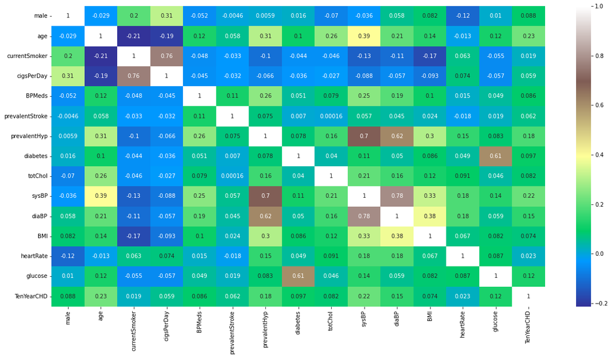

```python
plt.figure(figsize=(20,10))
sns.heatmap(df.corr(), annot=True, cmap='terrain')
```

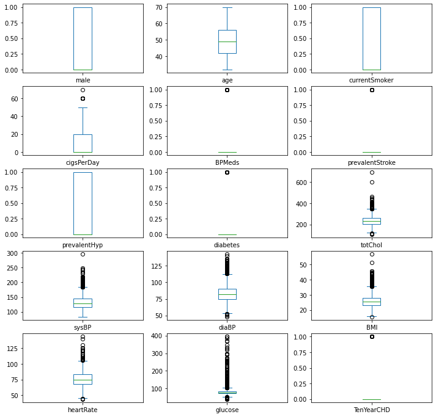

```python
df.plot(kind='box', subplots=True, layout=(5,3), figsize=(12,12))
plt.show()
```

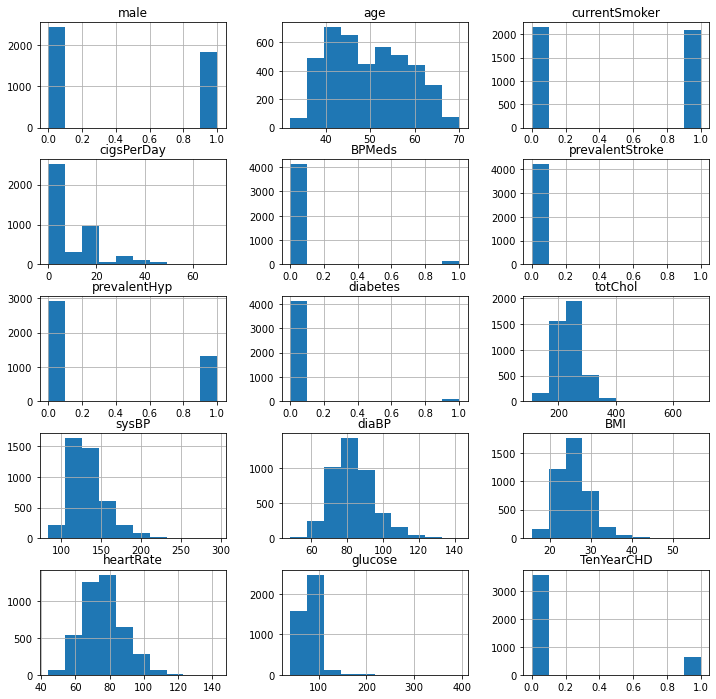

```python
df.hist(figsize=(12,12), layout=(5,3));
```

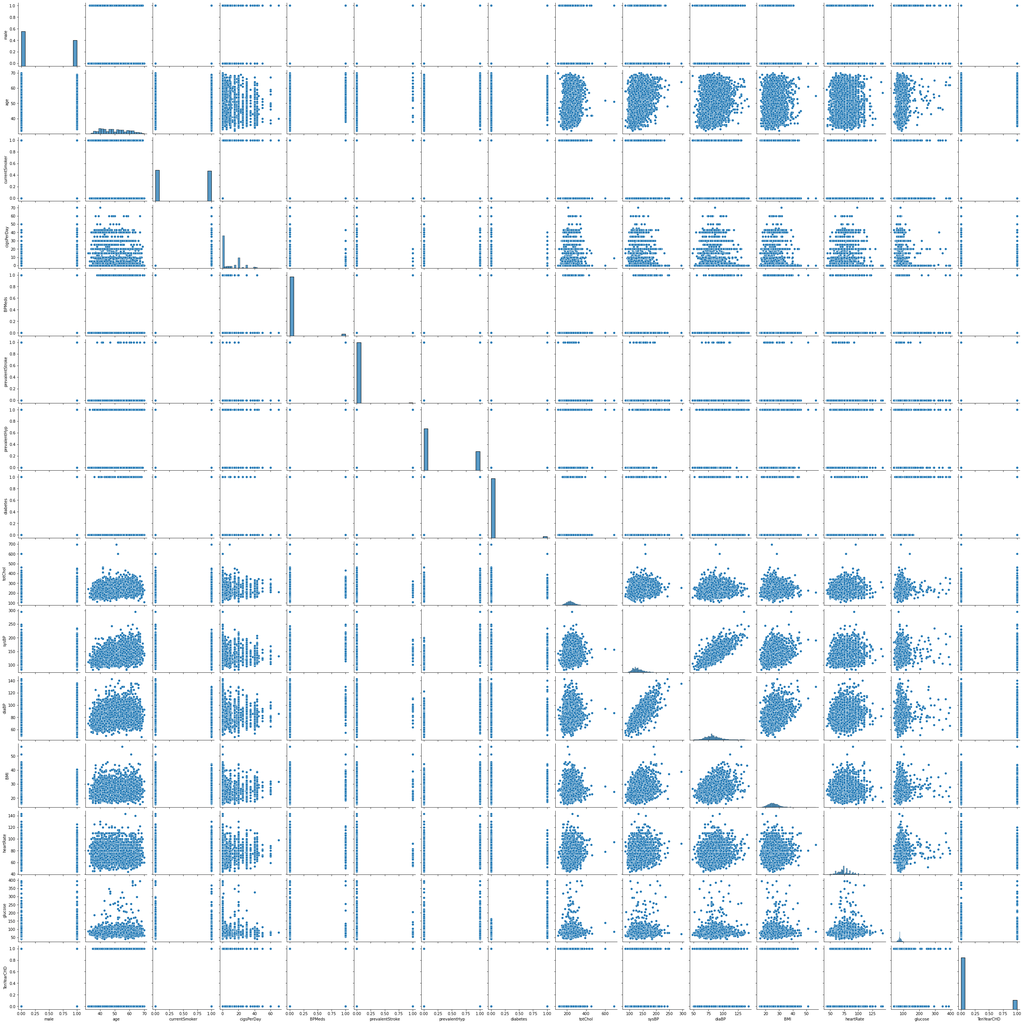

```python
sns.pairplot(data=df)
```

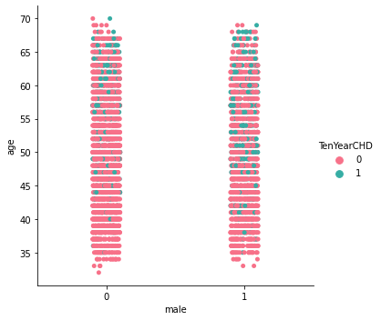

```python
sns.catplot(data=df, x='male', y='age',  hue='TenYearCHD',palette='husl')
```

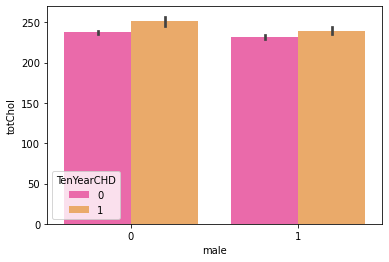

```python
sns.barplot(data=df, x='male', y='totChol', hue='TenYearCHD', palette='spring')
```

```python
df['male'].value_counts()
```

```
0    2420
1    1820
Name: male, dtype: int64
```

```python
df.head()
```

|  | male | age | currentSmoker | cigsPerDay | BPMeds | prevalentStroke | prevalentHyp | diabetes | totChol | sysBP | diaBP | BMI | heartRate | glucose | TenYearCHD |
| --- | --- | --- | --- | --- | --- | --- | --- | --- | --- | --- | --- | --- | --- | --- | --- |
| 0 | 1 | 39 | 0 | 0.0 | 0.0 | 0 | 0 | 0 | 195.0 | 106.0 | 70.0 | 26.97 | 80.0 | 77.0 | 0 |
| 1 | 0 | 46 | 0 | 0.0 | 0.0 | 0 | 0 | 0 | 250.0 | 121.0 | 81.0 | 28.73 | 95.0 | 76.0 | 0 |
| 2 | 1 | 48 | 1 | 20.0 | 0.0 | 0 | 0 | 0 | 245.0 | 127.5 | 80.0 | 25.34 | 75.0 | 70.0 | 0 |
| 3 | 0 | 61 | 1 | 30.0 | 0.0 | 0 | 1 | 0 | 225.0 | 150.0 | 95.0 | 28.58 | 65.0 | 103.0 | 1 |
| 4 | 0 | 46 | 1 | 23.0 | 0.0 | 0 | 0 | 0 | 285.0 | 130.0 | 84.0 | 23.10 | 85.0 | 85.0 | 0 |

```python
df['TenYearCHD'].value_counts()
```

```
0    3596
1     644
Name: TenYearCHD, dtype: int64
```

3596 cases of no heart diseases and 644 cases of heart diseases

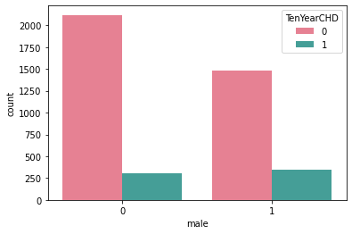

```python
sns.countplot(x='male', data=df, palette='husl', hue='TenYearCHD')
```

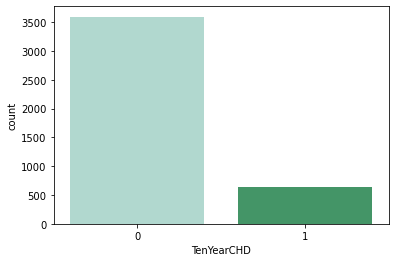

```python
sns.countplot(x='TenYearCHD',palette='BuGn', data=df)
```

we observe the count for not having heart disease is more than the count of having heart disease

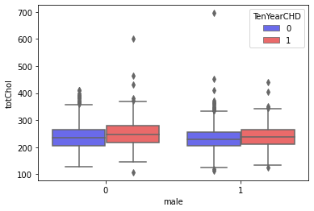

```python
sns.boxplot(x='male', y='totChol', hue='TenYearCHD', palette='seismic', data=df)
```

```python
df['prevalentHyp'].value_counts()
```

```
0    2923
1    1317
Name: prevalentHyp, dtype: int64
```

# Preparing the data for Model

Scaling the data

```python
from sklearn.preprocessing import StandardScaler
StandardScaler = StandardScaler()
columns_to_scale = ['age','cigsPerDay','totChol','sysBP','diaBP', 'BMI', 'heartRate', 'glucose']
df[columns_to_scale] = StandardScaler.fit_transform(df[columns_to_scale])
```

```python
from sklearn.model_selection import train_test_split
```

```python
df.head()
```

|  | male | age | currentSmoker | cigsPerDay | BPMeds | prevalentStroke | prevalentHyp | diabetes | totChol | sysBP | diaBP | BMI | heartRate | glucose | TenYearCHD |
| --- | --- | --- | --- | --- | --- | --- | --- | --- | --- | --- | --- | --- | --- | --- | --- |
| 0 | 1 | -1.234283 | 0 | -0.751412 | 0.0 | 0 | 0 | 0 | -0.940086 | -1.196267 | -1.083027 | 0.287693 | 0.342792 | -0.201287 | 0 |
| 1 | 0 | -0.417664 | 0 | -0.751412 | 0.0 | 0 | 0 | 0 | 0.300797 | -0.515399 | -0.159355 | 0.720094 | 1.590451 | -0.245036 | 0 |
| 2 | 1 | -0.184345 | 1 | 0.928784 | 0.0 | 0 | 0 | 0 | 0.187990 | -0.220356 | -0.243325 | -0.112769 | -0.073094 | -0.507530 | 0 |
| 3 | 0 | 1.332233 | 1 | 1.768882 | 0.0 | 0 | 1 | 0 | -0.263241 | 0.800946 | 1.016227 | 0.683242 | -0.904866 | 0.936188 | 1 |
| 4 | 0 | -0.417664 | 1 | 1.180813 | 0.0 | 0 | 0 | 0 | 1.090450 | -0.106878 | 0.092555 | -0.663098 | 0.758678 | 0.148705 | 0 |

```python
X= df.drop(['TenYearCHD'], axis=1)
y= df['TenYearCHD']
```

```python
X_train, X_test,y_train, y_test=train_test_split(X,y,test_size=0.2,random_state=40)
```

Check the sample Size

```python
print('X_train-', X_train.size)
print('X_test-',X_test.size)
print('y_train-', y_train.size)
print('y_test-', y_test.size)
```

```
X_train- 47488
X_test- 11872
y_train- 3392
y_test- 848
```

# Logistic Regression

```python
from sklearn.linear_model import LogisticRegression
lr=LogisticRegression()

model1=lr.fit(X_train,y_train)
prediction1=model1.predict(X_test)
```

```python
from sklearn.metrics import confusion_matrix

cm=confusion_matrix(y_test,prediction1)
cm
```

```
array([[719,   4],
       [116,   9]], dtype=int64)
```

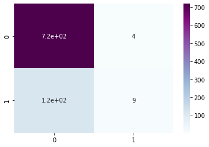

```python
sns.heatmap(cm, annot=True,cmap='BuPu')
```

```python
TP=cm[0][0]
TN=cm[1][1]
FN=cm[1][0]
FP=cm[0][1]
print('Testing Accuracy:',(TP+TN)/(TP+TN+FN+FP))
```

```
Testing Accuracy: 0.8584905660377359
```

```python
from sklearn.metrics import accuracy_score
accuracy_score(y_test,prediction1)
```

```
0.8584905660377359
```

```python
from sklearn.metrics import classification_report
print(classification_report(y_test, prediction1))
```

```
              precision    recall  f1-score   support

           0       0.86      0.99      0.92       723
           1       0.69      0.07      0.13       125

    accuracy                           0.86       848
   macro avg       0.78      0.53      0.53       848
weighted avg       0.84      0.86      0.81       848
```

# Decision Tree

```python
from sklearn.tree import DecisionTreeClassifier

dtc=DecisionTreeClassifier()
model2=dtc.fit(X_train,y_train)
prediction2=model2.predict(X_test)
cm2= confusion_matrix(y_test,prediction2)
```

```python
cm2
```

```
array([[607, 116],
       [ 92,  33]], dtype=int64)
```

```python
accuracy_score(y_test,prediction2)
```

```
0.7547169811320755
```

```python
print(classification_report(y_test, prediction2))
```

```
              precision    recall  f1-score   support

           0       0.87      0.84      0.85       723
           1       0.22      0.26      0.24       125

    accuracy                           0.75       848
   macro avg       0.54      0.55      0.55       848
weighted avg       0.77      0.75      0.76       848
```

# Random Forest

```python
from sklearn.ensemble import RandomForestClassifier

rfc=RandomForestClassifier()
model3 = rfc.fit(X_train, y_train)
prediction3 = model3.predict(X_test)
confusion_matrix(y_test, prediction3)
```

```
array([[717,   6],
       [115,  10]], dtype=int64)
```

```python
accuracy_score(y_test, prediction3)
```

```
0.8573113207547169
```

```python
print(classification_report(y_test, prediction3))
```

```
              precision    recall  f1-score   support

           0       0.86      0.99      0.92       723
           1       0.62      0.08      0.14       125

    accuracy                           0.86       848
   macro avg       0.74      0.54      0.53       848
weighted avg       0.83      0.86      0.81       848
```

```python
from sklearn.model_selection import KFold
from sklearn.model_selection import cross_val_score
```

```python
from sklearn.svm import SVC

svm=SVC()
model4=svm.fit(X_train,y_train)
prediction4=model4.predict(X_test)
cm4= confusion_matrix(y_test,prediction4)
```

```python
cm4
```

```
array([[721,   2],
       [121,   4]], dtype=int64)
```

```python
accuracy_score(y_test, prediction4)
```

```
0.8549528301886793
```

```python
from sklearn.naive_bayes import GaussianNB

NB = GaussianNB()
model5 = NB.fit(X_train, y_train)
prediction5 = model5.predict(X_test)
cm5= confusion_matrix(y_test, prediction5)
```

```python
cm5
```

```
array([[673,  50],
       [102,  23]], dtype=int64)
```

```python
accuracy_score(y_test, prediction5)
```

```
0.8207547169811321
```

```python
print('cm4', cm4)
print('-----------')
print('cm5',cm5)
```

```
cm4 [[721   2]
 [121   4]]
-----------
cm5 [[673  50]
 [102  23]]
```

```python
from sklearn.neighbors import KNeighborsClassifier

KNN = KNeighborsClassifier()
model6 = KNN.fit(X_train, y_train)
prediction6 = model6.predict(X_test)
cm6= confusion_matrix(y_test, prediction5)
cm6
```

```
array([[673,  50],
       [102,  23]], dtype=int64)
```

```python
accuracy_score(y_test,prediction6)
```

```
0.8325471698113207
```

```python
print('KNN :', accuracy_score(y_test, prediction6))
print('lr :', accuracy_score(y_test, prediction1))
print('dtc :', accuracy_score(y_test, prediction2))
print('rfc :', accuracy_score(y_test, prediction3))
print('NB: ', accuracy_score(y_test, prediction4))
print('SVC :', accuracy_score(y_test, prediction5))
```

```
KNN : 0.8325471698113207
lr : 0.8584905660377359
dtc : 0.7547169811320755
rfc : 0.8573113207547169
NB:  0.8549528301886793
SVC : 0.8207547169811321
```

Best accuracy is given by Logistic Regression :0.8584905660377359